# Algoritma Academy: Time Series & Forecasting

In other words, you can’t decompose the above time series any further, for each year there is exactly one observation (frequency = 1): and you can’t extract any pattern of seasonality from a time series where frequency is 1.

**Dive Deeper**: `presidents` is a built-in dataset recording the quarterly Approval Ratings of US Presidents.

1. What is the class of `presidents`? If it is not a time series object, convert it to a time series object.
2. Plot the time series.
3. 2 hours and 8 minutes after John F.Kennedy’s assassination, amid suspicions of a conspiracy against the government, Lyndon Johnson was sworn in as president. His presidential term is between the last quarter of 1963 (hint: `start=c(1963,4)`) to the last quarter of 1968. Create a time series plot for that time window using the appropriate `start` and `end` parameters for the `window()` function.
4. Was Lydon Johnson a popular president during his presidential term?
5. As a bonus exercise, give the plot an appropriate main title and axis labels (x and y).

Reference Answer: Lydon Johnson is arguably one of the least popular president in US history, with backlash stemming from “Frustration over Vietnam; too much federal spending and… taxation; no great public support for your Great Society programs; and … public disenchantment with the civil rights programs”. Famously, he “could scarcely travel anywhere without facing protests” as people protested and chanted “Hey, hey, LBJ, how many kids did you kill today?”[^6]

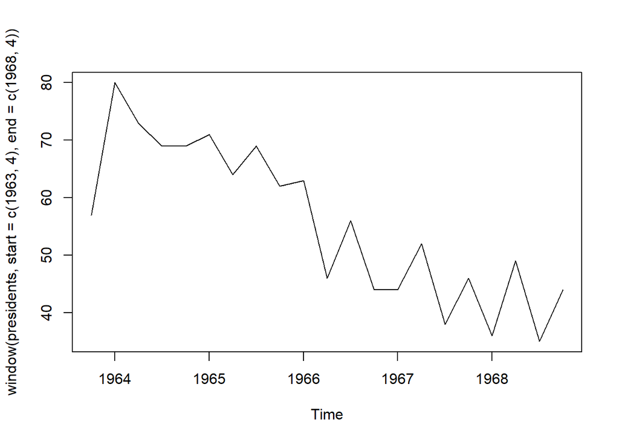

```r
plot(window(presidents, start=c(1963,4), end=c(1968,4)))
```

Let’s take a look at the following data instead. The following is monthly data starting from January 1946 corresponding to the number of births (thousands) per month in New York City:

```r
births <- read.csv("data_input/nybirth.csv")
str(births)
```

```
## 'data.frame':    168 obs. of  2 variables:
##  $ date  : chr  "1946-01-01" "1946-02-01" "1946-03-01" "1946-04-01" ...
##  $ births: num  26.7 23.6 26.9 24.7 25.8 ...
```

**Dive Deeper**: Referring to the code earlier, convert the above data frame to be a time series. Use the appropriate value for `frequency`, `start` and optionally, `end`. Plot the time series.

As you study your time series, you should notice that there are a considerable amount of “structural” pattern in your time series. We call these seasonal variation from year to year “seasonality”: birth rate is lower near winter (Jan - Feb) and peaks in July (summer weather).

I marked the “February” months with a dark red points and the “July” months with a blue point to highlight that year to year variation. Your `plot` function should be called on a timeseries object and not on a dataframe like the code below as they are used for illustrative purposes only:

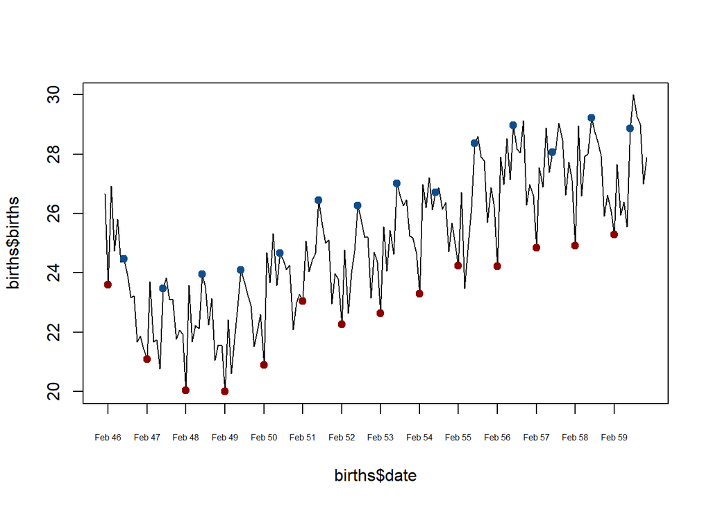

```r
library(dplyr)
library(lubridate)
births <- births %>%
  mutate(date = as.Date(date), month = month(date))

plot(births$date, births$births, type="l", xaxt="n")
points(
  x =  births[births$month == 2, "date"],
  y = births[births$month == 2, "births"], col="darkred", pch=19)
points(
  x =  births[births$month == 7, "date"],
  y = births[births$month == 7, "births"], col="dodgerblue4", pch=19)
axis(1, births$date[seq(2, length(births$date), by = 12)], format(births$date[seq(2, length(births$date), by = 12)], "%b %y"), cex.axis=0.5)
```

The reference answer to the above exercise:

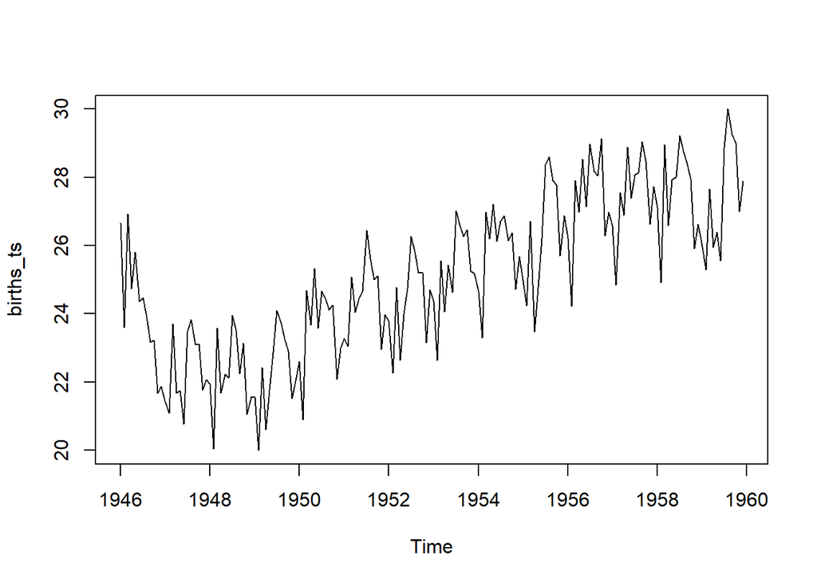

```r
births <- read.csv("data_input/nybirth.csv")
births_ts <- ts(births$births, frequency = 12, start = c(1946,1))
plot(births_ts)
```